# EasyVisa-Adv-ML-Project

## M1 : Decision Tree oversampled (sklearn default)

- The model will be trained on oversampled data

```python
#Train the decision tree on oversampled data
dtree_over = DecisionTreeClassifier(random_state=1)

# fitting the model to the over sampled training data
dtree_over.fit(X_train_over, y_train_over)
```

```
DecisionTreeClassifier(random_state=1)
```

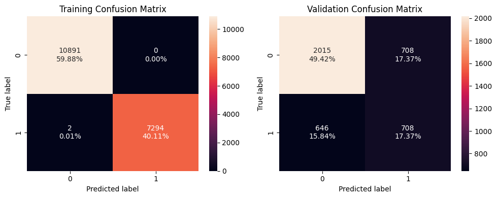

```python
# plot confusion matrices for training, validation data
plot_confusion_matrices_v2(dtree_over, X_train_over, y_train_over, X_val, y_val)
```

```python
# compute performance metrics on training data set
dtree_over_train_perf = model_performance_classification(
    dtree_over, X_train_over, y_train_over
)

# compute performance metrics on validation data
dtree_over_val_perf = model_performance_classification(
    dtree_over, X_val, y_val
)

# print and compare model performances
dtree_over_performance = model_performances(dtree_over_train_perf, dtree_over_val_perf)
dtree_over_performance
```

|  |  | Accuracy | Recall | Precision | F1 |
| --- | --- | --- | --- | --- | --- |
| Training | 0 | 0.999890 | 0.999726 | 1.0 | 0.999863 |
| Validation | 0 | 0.667893 | 0.522895 | 0.5 | 0.511191 |

### Model Summary

- Oversampled Decision tree model is performing marginally better on F1 Score, precision, Recall compared to the origin model.
- Still the model is overfitting as training scores are near perfect, but the validation scores are dropping significantly.

## M2 : Bagging Classifier oversampled

```python
#Train the bagging classifier on oversampled data
bagging_classifier_over = BaggingClassifier(random_state=1)

# fitting the model to the over sampled training data
bagging_classifier_over.fit(X_train_over, y_train_over)
```

```
BaggingClassifier(random_state=1)
```

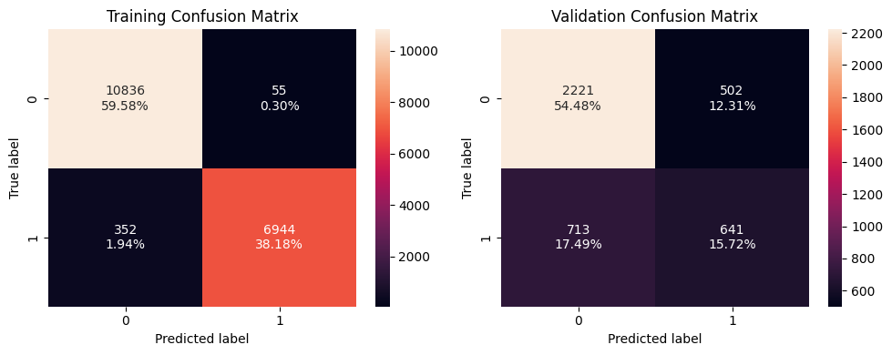

```python
# plot confusion matrices for training, validation data
plot_confusion_matrices_v2(bagging_classifier_over, X_train_over, y_train_over, X_val, y_val)
```

```python
# compute performance metrics on training data set
bagging_classifier_over_train_perf = model_performance_classification(
    bagging_classifier_over, X_train_over, y_train_over
)

# compute performance metrics on validation data
bagging_classifier_over_val_perf = model_performance_classification(
    bagging_classifier_over, X_val, y_val
)

# print and compare model performances
bagging_classifier_over_performance = model_performances(bagging_classifier_over_train_perf, bagging_classifier_over_val_perf)
bagging_classifier_over_performance
```

|  |  | Accuracy | Recall | Precision | F1 |
| --- | --- | --- | --- | --- | --- |
| Training | 0 | 0.977621 | 0.951754 | 0.992142 | 0.971529 |
| Validation | 0 | 0.701987 | 0.473412 | 0.560805 | 0.513416 |

### Model Summary

- There is a marginal improvement in F1 score after oversampling compared to the model built on the original data, but the gain is not significant.
- The model still shows signs of overfitting, with a noticeable gap between training and validation metrics such as F1, Precision, and Recall.

## M3 : Random Forest Classifier oversampled

- The model will be trained on oversampled data

```python
#Train the random forest classifier on oversampled data
rf_classifier_over = RandomForestClassifier(random_state=1)

# fitting the model to the over sampled training data
rf_classifier_over.fit(X_train_over, y_train_over)
```

```
RandomForestClassifier(random_state=1)
```

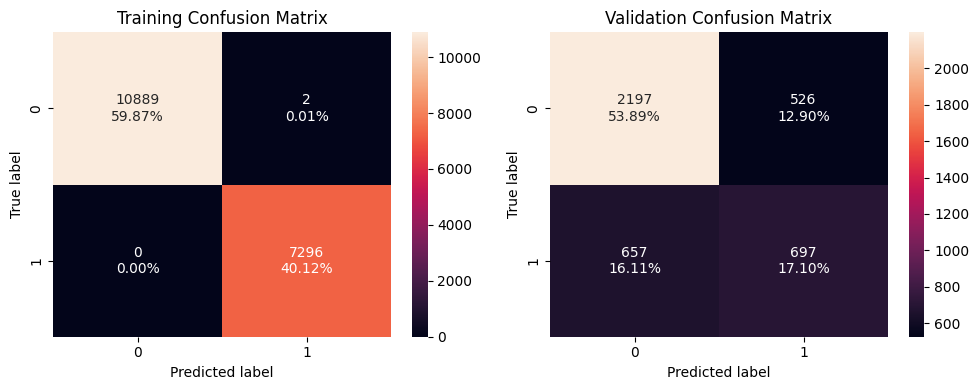

```python
# plot confusion matrices for training, validation data
plot_confusion_matrices_v2(rf_classifier_over, X_train_over, y_train_over, X_val, y_val)
```

```python
# compute performance metrics on training data set
rf_classifier_over_train_perf = model_performance_classification(
    rf_classifier_over, X_train_over, y_train_over
)

# compute performance metrics on validation data
rf_classifier_over_val_perf = model_performance_classification(
    rf_classifier_over, X_val, y_val
)

# print and compare model performances
rf_classifier_over_performance = model_performances(rf_classifier_over_train_perf, rf_classifier_over_val_perf)
rf_classifier_over_performance
```

|  |  | Accuracy | Recall | Precision | F1 |
| --- | --- | --- | --- | --- | --- |
| Training | 0 | 0.999890 | 1.000000 | 0.999726 | 0.999863 |
| Validation | 0 | 0.709836 | 0.514771 | 0.569910 | 0.540939 |

### Model Summary

- Slight improvement in validation F1 score, accuracy after oversampling and also recall has a modest gain.
- Training metrics are near-perfect in both cases, suggesting the model is highly overfitting regardless of oversampling.

## M4 : AdaBoostClassifier oversampled

- The model will be trained on oversampled data

```python
#Train the adaboost classifier on oversampled data
ada_boost_classifier_over = AdaBoostClassifier(random_state=1)

# fitting the model to the over sampled training data
ada_boost_classifier_over.fit(X_train_over, y_train_over)
```

```
AdaBoostClassifier(random_state=1)
```

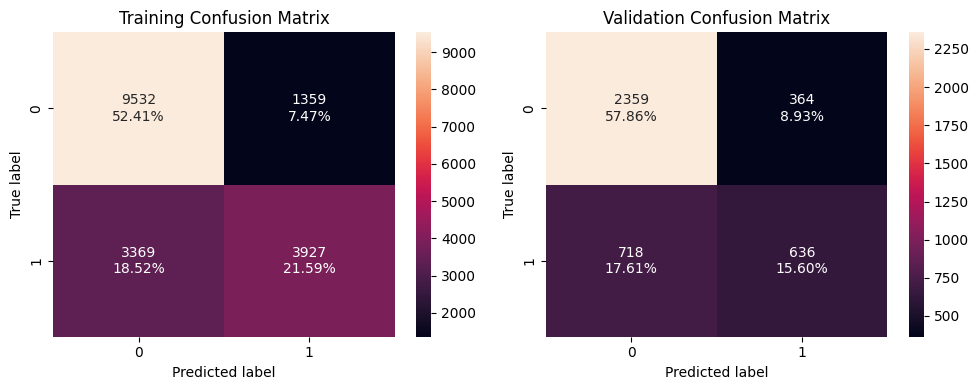

```python
# plot confusion matrices for training, validation data
plot_confusion_matrices_v2(ada_boost_classifier_over, X_train_over, y_train_over, X_val, y_val)
```

```python
# compute performance metrics on training data set
ada_boost_classifier_over_train_perf = model_performance_classification(
    ada_boost_classifier_over, X_train_over, y_train_over
)

# compute performance metrics on validation data
ada_boost_classifier_over_val_perf = model_performance_classification(
    ada_boost_classifier_over, X_val, y_val
)

# print and compare model performances
ada_boost_classifier_over_performance = model_performances(ada_boost_classifier_over_train_perf, ada_boost_classifier_over_val_perf)
ada_boost_classifier_over_performance
```

|  |  | Accuracy | Recall | Precision | F1 |
| --- | --- | --- | --- | --- | --- |
| Training | 0 | 0.740034 | 0.538240 | 0.742906 | 0.624225 |
| Validation | 0 | 0.734609 | 0.469719 | 0.636000 | 0.540357 |

### Model Summary

- F1 score and recall have improved marginally after oversampling, compared to the original data model. But the values of recall and F1 are relatively low, indicating the model is missing many positive (minority) cases.
- Precision scores are reasonable but not strong. This model may be a baseline, but would likely need improvement via tuning, better features, or alternative algorithms for production use.
- The model doesn't appear to be overfitting and is generalising, as the gaps are modest, not extreme between training and validation data of the oversampled model

## M5 : Gradient Boost Classifier oversampled

- The model will be trained on oversampled data

```python
#Train the gradient boost classifier on oversampled data
gradient_boost_classifier_over = GradientBoostingClassifier(random_state=1)

# fitting the model to the over sampled training data
gradient_boost_classifier_over.fit(X_train_over, y_train_over)
```

```
GradientBoostingClassifier(random_state=1)
```

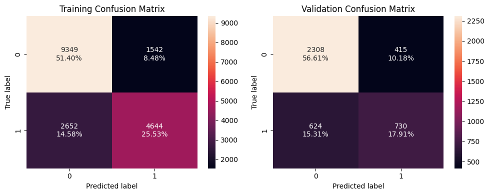

```python
# plot confusion matrices for training, validation data
plot_confusion_matrices_v2(gradient_boost_classifier_over, X_train_over, y_train_over, X_val, y_val)
```

```python
# compute performance metrics on training data set
gradient_boost_classifier_over_train_perf = model_performance_classification(
    gradient_boost_classifier_over, X_train_over, y_train_over
)

# compute performance metrics on validation data
gradient_boost_classifier_over_val_perf = model_performance_classification(
    gradient_boost_classifier_over, X_val, y_val
)

# print and compare model performances
gradient_boost_classifier_over_performance = model_performances(gradient_boost_classifier_over_train_perf, gradient_boost_classifier_over_val_perf)
gradient_boost_classifier_over_performance
```

|  |  | Accuracy | Recall | Precision | F1 |
| --- | --- | --- | --- | --- | --- |
| Training | 0 | 0.769396 | 0.636513 | 0.750727 | 0.688919 |
| Validation | 0 | 0.745156 | 0.539143 | 0.637555 | 0.584234 |

### Model summary

- Oversampling has improved all training metrics, for Recall, F1 showing better learning of the minority class.
- Validation F1 also improved slightly (to 0.584), mainly due to higher recall, suggesting improved generalization.
- Small gap between training and validation metrics indicates limited overfitting and a good balance between learning and generalization.
- The main challenges remain around limited generalization, moderate recall, and mild overfitting

## M6 : XG Boost Classifier oversampled

- The model will be trained on oversampled data

```python
#Train the XG Boost classifier on oversampled data
xg_boost_classifier_over = XGBClassifier(random_state=1, eval_metric = 'logloss')

# fitting the model to the over sampled training data
xg_boost_classifier_over.fit(X_train_over, y_train_over)
```

```
XGBClassifier(base_score=None, booster=None, callbacks=None,
              colsample_bylevel=None, colsample_bynode=None,
              colsample_bytree=None, device=None, early_stopping_rounds=None,
              enable_categorical=False, eval_metric='logloss',
              feature_types=None, feature_weights=None, gamma=None,
              grow_policy=None, importance_type=None,
              interaction_constraints=None, learning_rate=None, max_bin=None,
              max_cat_threshold=None, max_cat_to_onehot=None,
              max_delta_step=None, max_depth=None, max_leaves=None,
              min_child_weight=None, missing=nan, monotone_constraints=None,
              multi_strategy=None, n_estimators=None, n_jobs=None,
              num_parallel_tree=None, ...)
```

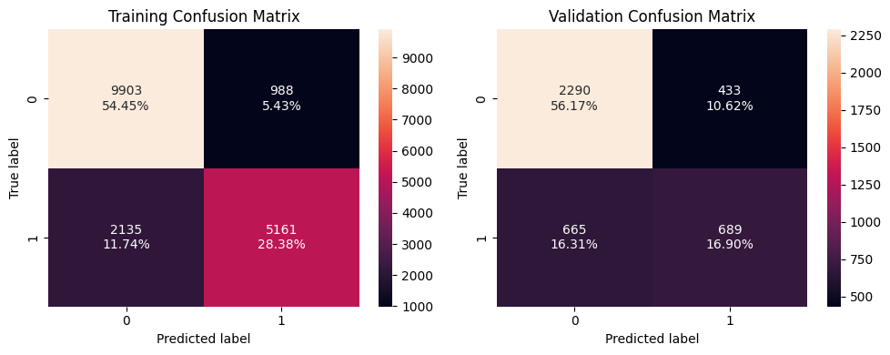

```python
# plot confusion matrices for training, validation data
plot_confusion_matrices_v2(xg_boost_classifier_over, X_train_over, y_train_over, X_val, y_val)
```

```python
# compute performance metrics on training data set
xg_boost_classifier_over_train_perf = model_performance_classification(
    xg_boost_classifier_over, X_train_over, y_train_over
)

# compute performance metrics on validation data
xg_boost_classifier_over_val_perf = model_performance_classification(
    xg_boost_classifier_over, X_val, y_val
)

# print and compare model performances
xg_boost_classifier_over_performance = model_performances(xg_boost_classifier_over_train_perf, xg_boost_classifier_over_val_perf)
xg_boost_classifier_over_performance
```

|  |  | Accuracy | Recall | Precision | F1 |
| --- | --- | --- | --- | --- | --- |
| Training | 0 | 0.828284 | 0.707374 | 0.839323 | 0.767720 |
| Validation | 0 | 0.730684 | 0.508863 | 0.614082 | 0.556543 |

# **5. Model Building - Undersampled Data**

```python
# fit random under sampler on the train data
random_under_sampler = RandomUnderSampler(random_state=1, sampling_strategy = 1)
X_train_under, y_train_under = random_under_sampler.fit_resample(X_train, y_train)
```

```python
# get the new dataset size before and after under sampling
create_sample_comparison(X_train, y_train, X_train_under, y_train_under)
```

|  | Label 1 Count | Label 0 Count | X Shape | y Shape |
| --- | --- | --- | --- | --- |
| Before Sampling | 5416 | 10891 | (16307, 20) | (16307,) |
| After Sampling | 5416 | 5416 | (10832, 20) | (10832,) |

## M1 : Decision Tree undersampled (sklearn default)

- The model will be trained on under sampled data

```python
#Train the decision tree on under sampled data
dtree_under = DecisionTreeClassifier(random_state=1)

# fitting the model to the under sampled training data
dtree_under.fit(X_train_under, y_train_under)
```

```
DecisionTreeClassifier(random_state=1)
```

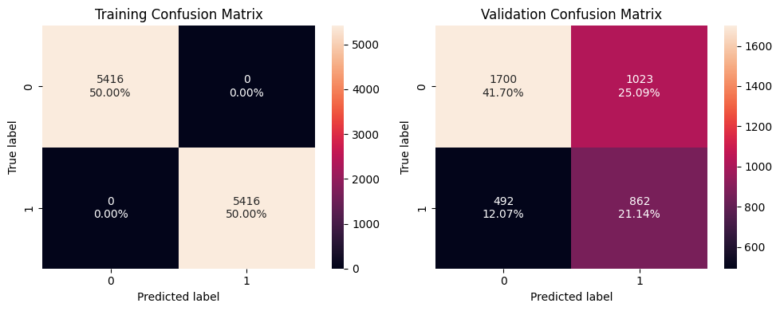

```python
# plot confusion matrices for training data undersampled and validation data
plot_confusion_matrices_v2(dtree_under, X_train_under, y_train_under, X_val, y_val)
```

```python
# compute performance metrics on training data set
dtree_under_train_perf = model_performance_classification(
    dtree_under, X_train_under, y_train_under
)

# compute performance metrics on validation data
dtree_under_val_perf = model_performance_classification(
    dtree_under, X_val, y_val
)

# print and compare model performances
dtree_under_performance = model_performances(dtree_under_train_perf, dtree_under_val_perf)
dtree_under_performance
```

|  |  | Accuracy | Recall | Precision | F1 |
| --- | --- | --- | --- | --- | --- |
| Training | 0 | 1.000000 | 1.000000 | 1.000000 | 1.000000 |
| Validation | 0 | 0.628403 | 0.636632 | 0.457294 | 0.532263 |

### Model summary

- F1 score and recall have marginal improvement for the undersampled model compared to the decision tree models from original data and oversampled data. Also, accuracy and precision have dropped in the undersampled model
- The model is still overfitting as the difference in training validation data is high

## M2 : Bagging Classifier undersampled

- The model will be trained on under sampled data

```python
#Train the decision tree on under sampled data
bagging_classifier_under = BaggingClassifier(random_state=1)

# fitting the model to the under sampled training data
bagging_classifier_under.fit(X_train_under, y_train_under)
```

```
BaggingClassifier(random_state=1)
```

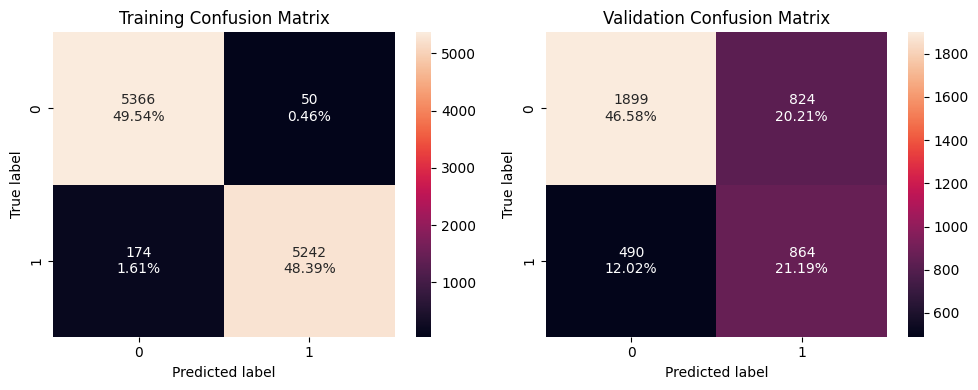

```python
# plot confusion matrices for training data undersampled and validation data
plot_confusion_matrices_v2(bagging_classifier_under, X_train_under, y_train_under, X_val, y_val)
```

```python
# compute performance metrics on training data set
bagging_classifier_under_train_perf = model_performance_classification(
    bagging_classifier_under, X_train_under, y_train_under
)

# compute performance metrics on validation data
bagging_classifier_under_val_perf = model_performance_classification(
    bagging_classifier_under, X_val, y_val
)

# print and compare model performances
bagging_classifier_under_performance = model_performances(bagging_classifier_under_train_perf, bagging_classifier_under_val_perf)
bagging_classifier_under_performance
```

|  |  | Accuracy | Recall | Precision | F1 |
| --- | --- | --- | --- | --- | --- |
| Training | 0 | 0.979321 | 0.967873 | 0.990552 | 0.979081 |
| Validation | 0 | 0.677704 | 0.638109 | 0.511848 | 0.568047 |

### Model summary

- Similar pattern like undersampled decision tree can be observed here in undersampled bagging classifier. There is a noticeable increase in recall and marginal increase in F1 score. But, there is also a drop in precision and accuracy
- Undersampled bagging classifier model is still overfitting as the gap is high between oversamples training and validation data

## M3: Random Forest Classifier undersampled

- The model will be trained on under sampled data

```python
#Train the random forest classifier on under sampled data
rf_classifier_under = RandomForestClassifier(random_state=1)

# fitting the model to the under sampled training data
rf_classifier_under.fit(X_train_under, y_train_under)
```

```
RandomForestClassifier(random_state=1)
```

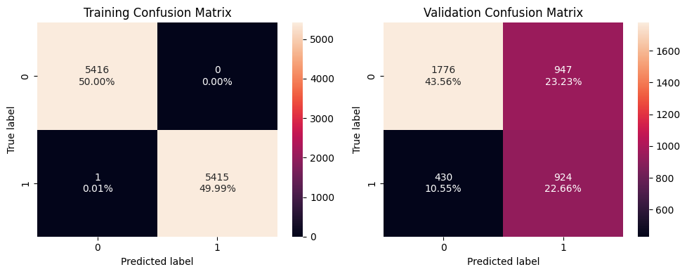

```python
# plot confusion matrices for training data undersampled and validation data
plot_confusion_matrices_v2(rf_classifier_under, X_train_under, y_train_under, X_val, y_val)
```

```python
# compute performance metrics on training data set
rf_classifier_under_train_perf = model_performance_classification(
    rf_classifier_under, X_train_under, y_train_under
)

# compute performance metrics on validation data
rf_classifier_under_val_perf = model_performance_classification(
    rf_classifier_under, X_val, y_val
)

# print and compare model performances
rf_classifier_under_performance = model_performances(rf_classifier_under_train_perf, rf_classifier_under_val_perf)
rf_classifier_under_performance
```

|  |  | Accuracy | Recall | Precision | F1 |
| --- | --- | --- | --- | --- | --- |
| Training | 0 | 0.999908 | 0.999815 | 1.000000 | 0.999908 |
| Validation | 0 | 0.662252 | 0.682422 | 0.493854 | 0.573023 |

### Model summary

- F1 score has marginally increased and recall has significantly increased due to the under sampling, but accuracy and precision have dropped
- Undersampled random forest classifier model is still overfitting as the gap is high between oversamples training and validation data

## M4 : Ada Boost Classifier undersampled

- The model will be trained on under sampled data

```python
#Train the Ada Boost classifier on under sampled data
ada_boost_classifier_under = AdaBoostClassifier(random_state=1)

# fitting the model to the under sampled training data
ada_boost_classifier_under.fit(X_train_under, y_train_under)
```

```
AdaBoostClassifier(random_state=1)
```

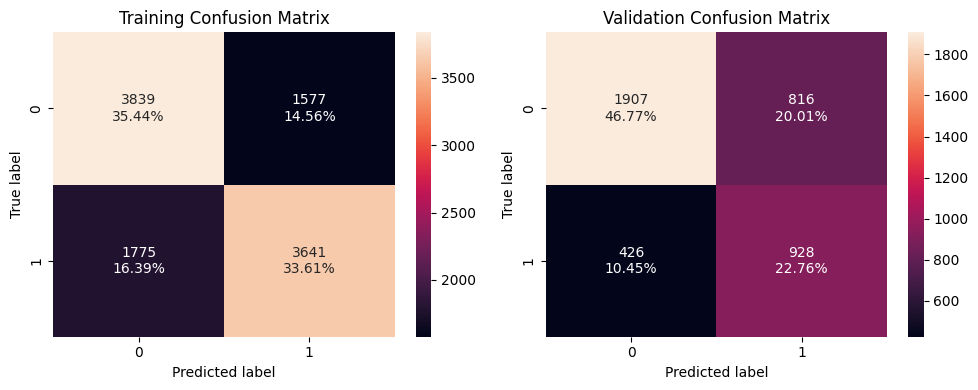

```python
# plot confusion matrices for training data undersampled and validation data
plot_confusion_matrices_v2(ada_boost_classifier_under, X_train_under, y_train_under, X_val, y_val)
```

```python
# compute performance metrics on training data set
ada_boost_classifier_under_train_perf = model_performance_classification(
    ada_boost_classifier_under, X_train_under, y_train_under
)

# compute performance metrics on validation data
ada_boost_classifier_under_val_perf = model_performance_classification(
    ada_boost_classifier_under, X_val, y_val
)

# print and compare model performances
ada_boost_classifier_under_performance = model_performances(ada_boost_classifier_under_train_perf, ada_boost_classifier_under_val_perf)
ada_boost_classifier_under_performance
```

|  |  | Accuracy | Recall | Precision | F1 |
| --- | --- | --- | --- | --- | --- |
| Training | 0 | 0.690547 | 0.672267 | 0.697777 | 0.684785 |
| Validation | 0 | 0.695364 | 0.685377 | 0.532110 | 0.599096 |

### Model summary

- F1 score has marginally increased and recall has significantly increased due to the under sampling, but accuracy and precision have dropped
- Undersampled Ada boost classifier is not overfitting as the difference between training and testing scores are not very high and similar for accuracy and recall

## M5 : Gradient Boost Classifier undersampled

- The model will be trained on under sampled data

```python
#Train the Gradient Boost classifier on under sampled data
gradient_boost_classifier_under = GradientBoostingClassifier(random_state=1)

# fitting the model to the under sampled training data
gradient_boost_classifier_under.fit(X_train_under, y_train_under)
```

```
GradientBoostingClassifier(random_state=1)
```

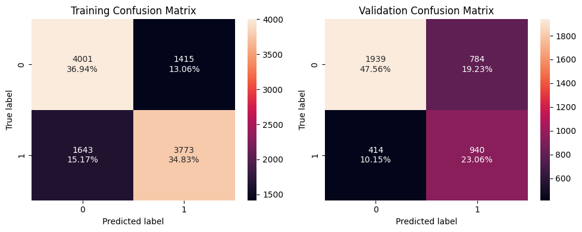

```python
# plot confusion matrices for training data undersampled and validation data
plot_confusion_matrices_v2(gradient_boost_classifier_under, X_train_under, y_train_under, X_val, y_val)
```

```python
# compute performance metrics on training data set
gradient_boost_classifier_under_train_perf = model_performance_classification(
    gradient_boost_classifier_under, X_train_under, y_train_under
)

# compute performance metrics on validation data
gradient_boost_classifier_under_val_perf = model_performance_classification(
    gradient_boost_classifier_under, X_val, y_val
)

# print and compare model performances
gradient_boost_classifier_under_performance = model_performances(gradient_boost_classifier_under_train_perf, gradient_boost_classifier_under_val_perf)
gradient_boost_classifier_under_performance
```

|  |  | Accuracy | Recall | Precision | F1 |
| --- | --- | --- | --- | --- | --- |
| Training | 0 | 0.717688 | 0.696640 | 0.727255 | 0.711618 |
| Validation | 0 | 0.706156 | 0.694239 | 0.545244 | 0.610786 |

### Model Summary

- Undersampling has resulted in increase in value of Recall for model created using gradient boosting and also a marginal increase in F1 score
- Precision and accuracy have dropped significantly
- Also, the model appears to be marginally overfitting as the gap in accuracy and recall is minimal but, the precision and F1 score do have noticeable difference

## M6 : XG Boost Classifier undersampled

- The model will be trained on under sampled data

```python
#Train the XG Boost classifier on under sampled data
xg_boost_classifier_under = XGBClassifier(random_state=1)

# fitting the model to the under sampled training data
xg_boost_classifier_under.fit(X_train_under, y_train_under)
```

```
XGBClassifier(base_score=None, booster=None, callbacks=None,
              colsample_bylevel=None, colsample_bynode=None,
              colsample_bytree=None, device=None, early_stopping_rounds=None,
              enable_categorical=False, eval_metric=None, feature_types=None,
              feature_weights=None, gamma=None, grow_policy=None,
              importance_type=None, interaction_constraints=None,
              learning_rate=None, max_bin=None, max_cat_threshold=None,
              max_cat_to_onehot=None, max_delta_step=None, max_depth=None,
              max_leaves=None, min_child_weight=None, missing=nan,
              monotone_constraints=None, multi_strategy=None, n_estimators=None,
              n_jobs=None, num_parallel_tree=None, ...)
```

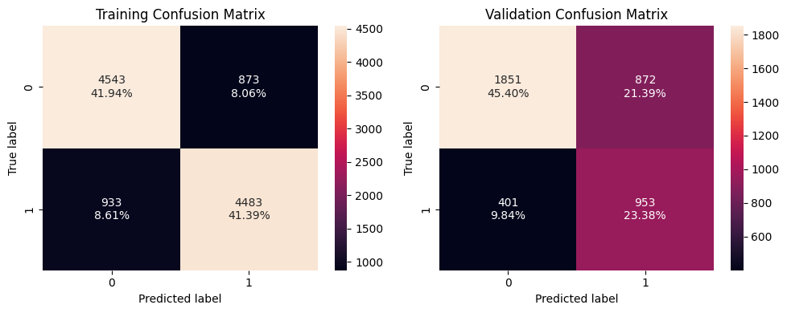

```python
# plot confusion matrices for training data undersampled and validation data
plot_confusion_matrices_v2(xg_boost_classifier_under, X_train_under, y_train_under, X_val, y_val)
```

```python
# compute performance metrics on training data set
xg_boost_classifier_under_train_perf = model_performance_classification(
    xg_boost_classifier_under, X_train_under, y_train_under
)

# compute performance metrics on validation data
xg_boost_classifier_under_val_perf = model_performance_classification(
    xg_boost_classifier_under, X_val, y_val
)

# print and compare model performances
xg_boost_classifier_under_performance = model_performances(xg_boost_classifier_under_train_perf, xg_boost_classifier_under_val_perf)
xg_boost_classifier_under_performance
```

|  |  | Accuracy | Recall | Precision | F1 |
| --- | --- | --- | --- | --- | --- |
| Training | 0 | 0.833272 | 0.827733 | 0.837005 | 0.832343 |
| Validation | 0 | 0.687761 | 0.703840 | 0.522192 | 0.599560 |

### Model summary

- For undersampled XGBoost, precision and accuracy have dropped. Recall has increased and also F1 score marginally
- The model is also moderately overfitting as there is gap between training and validation metrics

# **6. Hyperparameter Tuning**

Top 3 best performing models from the total 18 models (6 x3) will be chosen. i.e., from 6 different techniques x 3 different models per technique

1. Decision Tree
2. Bagging
3. Random Forest
4. AdaBoost
5. Gradient Boost
6. XG Boost

## Listing the model performances

```python
# Create the matrix to display the techniques and the models with their performance on training and testing data
all_model_names = [
  'Decision Tree simple',
  'Decision Tree oversampled',
  'Decision Tree undersampled',
  'Bagging simple',
  'Bagging oversampled',
  'Bagging undersampled',
  'Random Forest simple',
  'Random Forest oversampled',
  'Random Forest undersampled',
  'Ada Boost simple',
  'Ada Boost oversampled',
  'Ada Boost undersampled',
  'Gradient Boost simple',
  'Gradient Boost oversampled',
  'Gradient Boost undersampled',
  'XG Boost simple',
  'XG Boost oversampled',
  'XG Boost undersampled'
]

all_models_without_tuning = pd.concat([
	dtree_performance,
	dtree_over_performance,
	dtree_under_performance,
	bagging_classifier_performance,
	bagging_classifier_over_performance,
	bagging_classifier_under_performance,
	rf_classifier_performance,
	rf_classifier_over_performance,
	rf_classifier_under_performance,
	ada_boost_classifier_performance,
	ada_boost_classifier_over_performance,
	ada_boost_classifier_under_performance,
	gradient_boost_classifier_performance,
	gradient_boost_classifier_over_performance,
	gradient_boost_classifier_under_performance,
	xg_boost_classifier_performance,
	xg_boost_classifier_over_performance,
	xg_boost_classifier_under_performance
  ], axis =0, keys = all_model_names)
all_models_without_tuning
```

|  |  |  | Accuracy | Recall | Precision | F1 |
| --- | --- | --- | --- | --- | --- | --- |
| Decision Tree simple | Training | 0 | 0.999877 | 0.999631 | 1.000000 | 0.999815 |
|  | Validation | 0 | 0.660780 | 0.488922 | 0.489283 | 0.489102 |
| Decision Tree oversampled | Training | 0 | 0.999890 | 0.999726 | 1.000000 | 0.999863 |
|  | Validation | 0 | 0.667893 | 0.522895 | 0.500000 | 0.511191 |
| Decision Tree undersampled | Training | 0 | 1.000000 | 1.000000 | 1.000000 | 1.000000 |
|  | Validation | 0 | 0.628403 | 0.636632 | 0.457294 | 0.532263 |
| Bagging simple | Training | 0 | 0.976452 | 0.936669 | 0.991983 | 0.963533 |
|  | Validation | 0 | 0.707873 | 0.460857 | 0.575115 | 0.511685 |
| Bagging oversampled | Training | 0 | 0.977621 | 0.951754 | 0.992142 | 0.971529 |
|  | Validation | 0 | 0.701987 | 0.473412 | 0.560805 | 0.513416 |
| Bagging undersampled | Training | 0 | 0.979321 | 0.967873 | 0.990552 | 0.979081 |
|  | Validation | 0 | 0.677704 | 0.638109 | 0.511848 | 0.568047 |
| Random Forest simple | Training | 0 | 0.999755 | 0.999446 | 0.999815 | 0.999631 |
|  | Validation | 0 | 0.708119 | 0.491137 | 0.570326 | 0.527778 |
| Random Forest oversampled | Training | 0 | 0.999890 | 1.000000 | 0.999726 | 0.999863 |
|  | Validation | 0 | 0.709836 | 0.514771 | 0.569910 | 0.540939 |
| Random Forest undersampled | Training | 0 | 0.999908 | 0.999815 | 1.000000 | 0.999908 |
|  | Validation | 0 | 0.662252 | 0.682422 | 0.493854 | 0.573023 |
| Ada Boost simple | Training | 0 | 0.735267 | 0.427068 | 0.655798 | 0.517276 |
|  | Validation | 0 | 0.734118 | 0.447563 | 0.643312 | 0.527875 |
| Ada Boost oversampled | Training | 0 | 0.740034 | 0.538240 | 0.742906 | 0.624225 |
|  | Validation | 0 | 0.734609 | 0.469719 | 0.636000 | 0.540357 |
| Ada Boost undersampled | Training | 0 | 0.690547 | 0.672267 | 0.697777 | 0.684785 |
|  | Validation | 0 | 0.695364 | 0.685377 | 0.532110 | 0.599096 |
| Gradient Boost simple | Training | 0 | 0.753112 | 0.502770 | 0.671351 | 0.574958 |
|  | Validation | 0 | 0.747854 | 0.512555 | 0.653484 | 0.574503 |
| Gradient Boost oversampled | Training | 0 | 0.769396 | 0.636513 | 0.750727 | 0.688919 |
|  | Validation | 0 | 0.745156 | 0.539143 | 0.637555 | 0.584234 |
| Gradient Boost undersampled | Training | 0 | 0.717688 | 0.696640 | 0.727255 | 0.711618 |
|  | Validation | 0 | 0.706156 | 0.694239 | 0.545244 | 0.610786 |
| XG Boost simple | Training | 0 | 0.825596 | 0.632201 | 0.800748 | 0.706562 |
|  | Validation | 0 | 0.736326 | 0.508863 | 0.626934 | 0.561761 |
| XG Boost oversampled | Training | 0 | 0.828284 | 0.707374 | 0.839323 | 0.767720 |
|  | Validation | 0 | 0.730684 | 0.508863 | 0.614082 | 0.556543 |
| XG Boost undersampled | Training | 0 | 0.833272 | 0.827733 | 0.837005 | 0.832343 |
|  | Validation | 0 | 0.687761 | 0.703840 | 0.522192 | 0.599560 |

## Selecting the Top '3' Models for hyper-parameter tuning

### **Selected Models (oversampled)**

#### **1. Gradient Boost (Oversampled)**

- Precision: **0.6376**, one of the **highest**, aligning with the goal to reduce false positives.
- F1 Score: **0.5842**, strong balance between precision and recall.
- Recall: **0.5391**, decent enough to avoid high false negatives.
- Handles class imbalance well with oversampling + boosting synergy.

#### **2. XGBoost (Oversampled)**

- Precision: **0.6141**, competitive and consistent across variations.
- F1 Score: **0.5565**, reliable balance of predictive strength.
- Recall: **0.5089**, well above average for high-precision models.
- Robust and scalable, great for complex, high-volume production use cases.

#### **3. AdaBoost (Oversampled)**

- Precision: **0.6360**, very close to Gradient Boost. Also, great for minimizing incorrect visa certifications.
- F1 Score: **0.5404**, solid balance, outperforming simpler AdaBoost.
- Recall: **0.4697**, acceptable considering high precision.
- Simpler model with fast training, suitable for early-stage deployments.

## **1. Tuning AdaBoost (oversampled)**

**Hyper Parameters**

Following hyper parameters will be used for AdaBoost tuning

1. `base_estimator`: The base estimator from which the boosted ensemble is built. By default the base estimator is a decision tree with `max_depth=1` 2.`n_estimators`: The maximum number of estimators at which boosting is terminated. Default value is 50.
2. `learning_rate`: Learning rate shrinks the contribution of each classifier by learning_rate. There is a trade-off between learning_rate and n_estimators.

**Cross Validation**

For cross validation `GridSearchCV` will be used

- scoring will be done for precision and F1 score
- To parallelise `n_jobs=-1` will be used

```python
# Grid of parameters to choose from
ada_parameters = {
    #Different max_depth for estimator
    "estimator":[DecisionTreeClassifier(max_depth=3, random_state=1),
                 DecisionTreeClassifier(max_depth=4, random_state=1),
                 DecisionTreeClassifier(max_depth=5, random_state=1)],
    "n_estimators": [100, 200, 300, 400],
    "learning_rate": [0.1, 0.2]
}

# Precision and F1 scoring used to compare parameter combinations
ada_scoring = {
    'precision' : metrics.make_scorer(metrics.precision_score),
    'f1' : metrics.make_scorer(metrics.f1_score)
}

# Create and run the grid search for all above combinations of hyper params
# use ada_boost_classifier_over model
ada_grid_obj = GridSearchCV(ada_boost_classifier_over,
                        ada_parameters,
                        scoring=ada_scoring,
                        refit='f1',
                        cv=5,
                        n_jobs=-1)
ada_grid_obj = ada_grid_obj.fit(X_train_over, y_train_over)

# Set the clf to the best combination of parameters
ada_boost_classifier_tuned = ada_grid_obj.best_estimator_

# Fit the best algorithm to the data.
ada_boost_classifier_tuned.fit(X_train_over, y_train_over)
```

```
AdaBoostClassifier(estimator=DecisionTreeClassifier(max_depth=5,
                                                    random_state=1),
                   learning_rate=0.2, n_estimators=400, random_state=1)
```

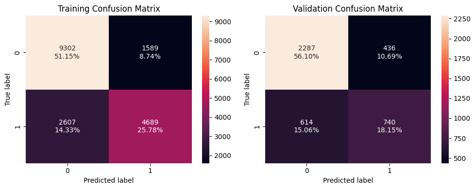

```python
# plot confusion matrices for training, validation data
plot_confusion_matrices_v2(ada_boost_classifier_tuned, X_train_over, y_train_over, X_val, y_val)
```

```python
# compute performance metrics on training data set
ada_boost_classifier_tuned_train_perf = model_performance_classification(
    ada_boost_classifier_tuned, X_train_over, y_train_over
)

# compute performance metrics on validation data
ada_boost_classifier_tuned_val_perf = model_performance_classification(
    ada_boost_classifier_tuned, X_val, y_val
)

# print and compare model performances
ada_boost_classifier_tuned_performance = model_performances(ada_boost_classifier_tuned_train_perf, ada_boost_classifier_tuned_val_perf)
ada_boost_classifier_tuned_performance
```

|  |  | Accuracy | Recall | Precision | F1 |
| --- | --- | --- | --- | --- | --- |
| Training | 0 | 0.769286 | 0.642681 | 0.746894 | 0.69088 |
| Validation | 0 | 0.742458 | 0.546529 | 0.629252 | 0.58498 |

### Importances

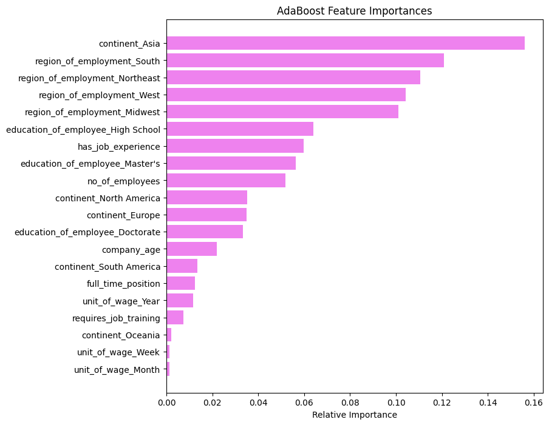

```python
# compute and print the important features
ada_boost_importances = ada_boost_classifier_tuned.feature_importances_
ada_indices = np.argsort(ada_boost_importances)
ada_feature_names = list(X.columns)

# plot the feature importance
plt.figure(figsize=(8,8))
plt.title('AdaBoost Feature Importances')
plt.barh(range(len(ada_indices)), ada_boost_importances[ada_indices], color='violet', align='center')
plt.yticks(range(len(ada_indices)), [ada_feature_names[i] for i in ada_indices])
plt.xlabel('Relative Importance')
plt.show()
```

**Observations**

- Adaboost hyper-tuned model considers the applicant country Asia as the important feature for applicants getting visas certified
- This is followed by various regions of employment and education level masters. High school education ranks high, but could be in negative filter context

## **2. Tuning Gradient Boost (oversampled)**

**Hyper Parameters**

Following hyper parameters will be used for Gradient Boost tuning on the oversampled model

1. `n_estimators`: number of boosting stages to perform. 2.`subsample`: fraction of samples to be used for fitting the individual base learners.
2. `max_features`: number of features to consider when looking for the best split
3. `learning_rate` : shrinks the contribution of each tree by learning_rate. There is a trade-off between learning_rate and n_estimators

**Cross Validation**

For cross validation `GridSearchCV` will be used

- scoring will be done for `precision` and `F1 score`
- To parallelise `n_jobs=-1` will be used

```python
# Grid of hyper parameters to choose from for GridSearchCV using Gradient Boosting
gb_parameters = {
    "n_estimators": [100, 150, 200, 250],
    "subsample":[0.8,0.9,1],
    "max_features":[0.7,0.8,0.9,1],
    "learning_rate":[0.1, 0.2, 0.3]
}

# Precision and F1 scoring used to compare parameter combinations
gb_scoring = {
    'precision' : metrics.make_scorer(metrics.precision_score),
    'f1' : metrics.make_scorer(metrics.f1_score)
}

# Create and run the grid search for all above combinations of hyper params
# use gradient_boost_classifier_over model
gb_grid_obj = GridSearchCV(gradient_boost_classifier_over,
                        gb_parameters,
                        scoring=gb_scoring,
                        refit='f1',
                        cv=5,
                        n_jobs=-1)
gb_grid_obj = gb_grid_obj.fit(X_train_over, y_train_over)

# Set the clf to the best combination of parameters
gradient_boost_classifier_tuned = gb_grid_obj.best_estimator_

# Fit the best algorithm to the data.
gradient_boost_classifier_tuned.fit(X_train_over, y_train_over)
```

```
GradientBoostingClassifier(max_features=0.7, n_estimators=150, random_state=1,
                           subsample=0.9)
```

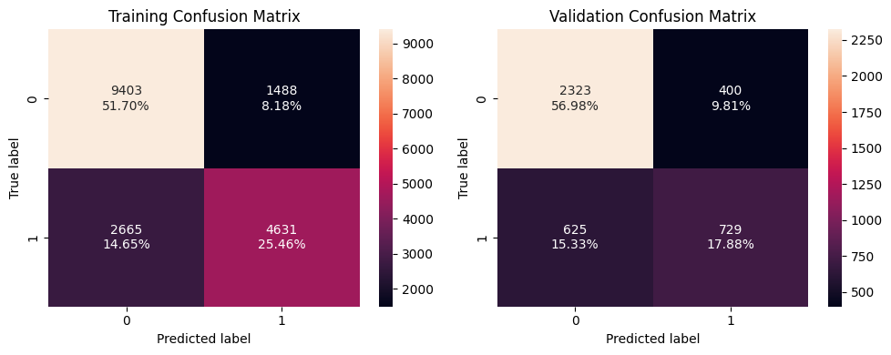

```python
# plot confusion matrices for training, validation data
plot_confusion_matrices_v2(gradient_boost_classifier_tuned, X_train_over, y_train_over, X_val, y_val)
```

```python
# compute performance metrics on training data set
gradient_boost_classifier_tuned_train_perf = model_performance_classification(
    gradient_boost_classifier_tuned, X_train_over, y_train_over
)

# compute performance metrics on validation data
gradient_boost_classifier_tuned_val_perf = model_performance_classification(
    gradient_boost_classifier_tuned, X_val, y_val
)

# print and compare model performances
gradient_boost_classifier_tuned_performance = model_performances(gradient_boost_classifier_tuned_train_perf, gradient_boost_classifier_tuned_val_perf)
gradient_boost_classifier_tuned_performance
```

|  |  | Accuracy | Recall | Precision | F1 |
| --- | --- | --- | --- | --- | --- |
| Training | 0 | 0.77165 | 0.634731 | 0.756823 | 0.690421 |
| Validation | 0 | 0.74859 | 0.538405 | 0.645704 | 0.587193 |

### Model Summary

- There is a marginal increase in Precision compared to the non-hyperparam tuned model
- Other metrics are almost the same between the tuned-oversampled-model to the non-tuned-oversampled model
- Model is overfitting very mild as the difference between oversampled training data and validation data is minimal

### Importances

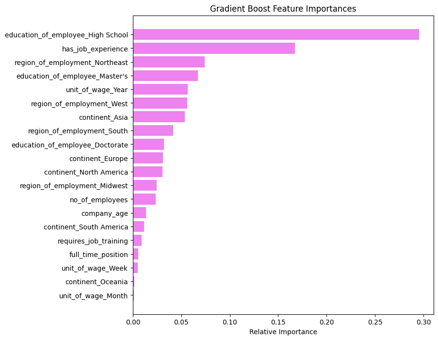

```python
# compute and print the important features
gradient_boost_importances = gradient_boost_classifier_tuned.feature_importances_
gb_indices = np.argsort(gradient_boost_importances)
gb_feature_names = list(X.columns)

# plot the feature importance
plt.figure(figsize=(8,8))
plt.title('Gradient Boost Feature Importances')
plt.barh(range(len(gb_indices)), gradient_boost_importances[gb_indices], color='violet', align='center')
plt.yticks(range(len(gb_indices)), [gb_feature_names[i] for i in gb_indices])
plt.xlabel('Relative Importance')
plt.show()
```

## **3. Tuning XG Boost (oversampled)**

**Hyper Parameters**

Following XGBoost hyper parameters will be used to tune to increase the model performance.

1. `n_estimators` : Number of boosting rounds
2. `scale_pos_weight` : Balancing of positive and negative weights.
3. `subsample` : Subsample ratio of the training instance
4. `learning_rate` : XGB's boosting learning rate
5. `gamma` : Minimum loss reduction required to make a further partition on a leaf node of the tree.
6. `colsample_bytree` : subsample ratio of columns when constructing each tree.
7. `colsample_bylevel` : subsample ratio of columns for each level.
8. `max_depth` : maximum depth for base learners

**Cross Validation**

For cross validation `GridSearchCV` will be used

- scoring will be done for `precision` and `F1 score`
- To parallelise `n_jobs=-1` will be used

```python
# Grid of hyper parameters to choose from for GridSearchCV using XG Boost
xgb_parameters = {
    "n_estimators": [100,150,200],
    "learning_rate":[0.1,0.2],
    "subsample":[0.6,0.7,0.9,1],
    "gamma":[0,0.5,1],
    "colsample_bytree":[0.7,0.9,1],
    "colsample_bylevel":[0.7,0.9,1],
    'max_depth': [3, 4, 5]
}

# Precision and F1 scoring used to compare parameter combinations
xgb_scoring = {
    'precision' : metrics.make_scorer(metrics.precision_score),
    'f1' : metrics.make_scorer(metrics.f1_score)
}

# Create and run the grid search for all above combinations of hyper params
xgb_grid_obj = GridSearchCV(xg_boost_classifier_over,
                        xgb_parameters,
                        scoring=xgb_scoring,
                        refit='f1',
                        cv=5,
                        n_jobs=-1)
xgb_grid_obj = xgb_grid_obj.fit(X_train_over, y_train_over)

# Set the clf to the best combination of parameters
xg_boost_classifier_tuned = xgb_grid_obj.best_estimator_

# Fit the best algorithm to the data.
xg_boost_classifier_tuned.fit(X_train_over, y_train_over)
```

```
XGBClassifier(base_score=None, booster=None, callbacks=None,
              colsample_bylevel=0.9, colsample_bynode=None, colsample_bytree=1,
              device=None, early_stopping_rounds=None, enable_categorical=False,
              eval_metric='logloss', feature_types=None, feature_weights=None,
              gamma=0.5, grow_policy=None, importance_type=None,
              interaction_constraints=None, learning_rate=0.1, max_bin=None,
              max_cat_threshold=None, max_cat_to_onehot=None,
              max_delta_step=None, max_depth=4, max_leaves=None,
              min_child_weight=None, missing=nan, monotone_constraints=None,
              multi_strategy=None, n_estimators=100, n_jobs=None,
              num_parallel_tree=None, ...)
```

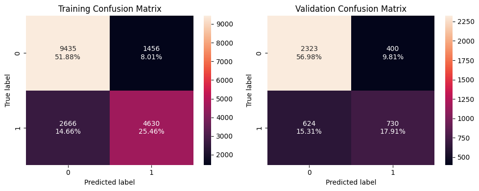

```python
# plot confusion matrices for training, validation data
plot_confusion_matrices_v2(xg_boost_classifier_tuned, X_train_over, y_train_over, X_val, y_val)
```

```python
# compute performance metrics on training data set
xg_boost_classifier_tuned_train_perf = model_performance_classification(
    xg_boost_classifier_tuned, X_train_over, y_train_over
)

# compute performance metrics on validation data
xg_boost_classifier_tuned_val_perf = model_performance_classification(
    xg_boost_classifier_tuned, X_val, y_val
)

# print and compare model performances
xg_boost_classifier_tuned_performance = model_performances(xg_boost_classifier_train_perf, xg_boost_classifier_val_perf)
xg_boost_classifier_tuned_performance
```

[output not shown]